# Modeling dataCar with tweedie Package

Seth Temple

```r
library(tweedie)
library(statmod)
library(ggplot2)
library(insuranceData)
```

Import the dataset.

```r
data(dataCar)
summary(dataCar)
```

```
   veh_value         exposure             clm            numclaims
 Min.   : 0.000   Min.   :0.002738   Min.   :0.00000   Min.   :0.00000
 1st Qu.: 1.010   1st Qu.:0.219028   1st Qu.:0.00000   1st Qu.:0.00000
 Median : 1.500   Median :0.446270   Median :0.00000   Median :0.00000
 Mean   : 1.777   Mean   :0.468651   Mean   :0.06814   Mean   :0.07276
 3rd Qu.: 2.150   3rd Qu.:0.709103   3rd Qu.:0.00000   3rd Qu.:0.00000
 Max.   :34.560   Max.   :0.999316   Max.   :1.00000   Max.   :4.00000

   claimcst0          veh_body        veh_age      gender    area          agecat
 Min.   :    0.0   SEDAN  :22233   Min.   :1.000   F:38603   A:16312   Min.   :1.000
 1st Qu.:    0.0   HBACK  :18915   1st Qu.:2.000   M:29253   B:13341   1st Qu.:2.000
 Median :    0.0   STNWG  :16261   Median :3.000             C:20540   Median :3.000
 Mean   :  137.3   UTE    : 4586   Mean   :2.674             D: 8173   Mean   :3.485
 3rd Qu.:    0.0   TRUCK  : 1750   3rd Qu.:4.000             E: 5912   3rd Qu.:5.000
 Max.   :55922.1   HDTOP  : 1579   Max.   :4.000             F: 3578   Max.   :6.000
                   (Other): 2532
                X_OBSTAT_
 01101    0    0    0:67856
```

There do not appear to be empties. We won’t do any additional wrangling. We have continuous numerical columns and some categorical columns. The target variable is claimcst0. We want to model loss costs with a Poisson-gamma model.

The naive approach is to set p as 1.5. Build this model with no features.

```r
m0 <- glm(claimcst0~1,
          data=dataCar,
          family=tweedie(link.power=0, var.power=1.5))
summary(m0)
```

```
Call:
glm(formula = claimcst0 ~ 1, family = tweedie(link.power = 0,
    var.power = 1.5), data = dataCar)

Deviance Residuals:
    Min       1Q   Median       3Q      Max
 -6.846   -6.846   -6.846   -6.846  131.329

Coefficients:
            Estimate Std. Error t value Pr(>|t|)
(Intercept)  4.92195    0.02954   166.6   <2e-16 ***
---
Signif. codes:  0 ‘***’ 0.001 ‘**’ 0.01 ‘*’ 0.05 ‘.’ 0.1 ‘ ’ 1

(Dispersion parameter for Tweedie family taken to be 693.7588)

    Null deviance: 5008639  on 67855  degrees of freedom
Residual deviance: 5008639  on 67855  degrees of freedom
AIC: NA

Number of Fisher Scoring iterations: 7
```

Explore the different variables. Improve the model.

```r
m1 <- glm(claimcst0~1+as.factor(gender),
          data=dataCar,
          family=tweedie(link.power=0, var.power=1.5))
summary(m1)
```

```
Call:
glm(formula = claimcst0 ~ 1 + as.factor(gender), family = tweedie(link.power = 0,
    var.power = 1.5), data = dataCar)

Deviance Residuals:
    Min       1Q   Median       3Q      Max
 -7.006   -7.006   -6.716   -6.716  128.001

Coefficients:
                   Estimate Std. Error t value Pr(>|t|)
(Intercept)         4.84544    0.03949 122.711  < 2e-16 ***
as.factor(gender)M  0.16926    0.05873   2.882  0.00395 **
---
Signif. codes:  0 ‘***’ 0.001 ‘**’ 0.01 ‘*’ 0.05 ‘.’ 0.1 ‘ ’ 1

(Dispersion parameter for Tweedie family taken to be 678.724)

    Null deviance: 5008639  on 67855  degrees of freedom
Residual deviance: 5003001  on 67854  degrees of freedom
AIC: NA

Number of Fisher Scoring iterations: 7
```

```r
anova(m1,m0)
```

```
Analysis of Deviance Table

Model 1: claimcst0 ~ 1 + as.factor(gender)
Model 2: claimcst0 ~ 1
  Resid. Df Resid. Dev Df Deviance
1     67854    5003001
2     67855    5008639 -1  -5637.6
```

```r
print("AIC change")
```

```
[1] "AIC change"
```

```r
print(AICtweedie(m1) - AICtweedie(m0))
```

```
[1] -8.496798
```

```r
m2 <- glm(claimcst0~1+as.factor(gender)+as.factor(agecat),
          data=dataCar,
          family=tweedie(link.power=0, var.power=1.5))
summary(m2)
```

```
Call:
glm(formula = claimcst0 ~ 1 + as.factor(gender) + as.factor(agecat),
    family = tweedie(link.power = 0, var.power = 1.5), data = dataCar)

Deviance Residuals:
    Min       1Q   Median       3Q      Max
 -7.941   -6.951   -6.703   -6.452  123.997

Coefficients:
                   Estimate Std. Error t value Pr(>|t|)
(Intercept)         5.34327    0.09174  58.242  < 2e-16 ***
as.factor(gender)M  0.17241    0.05849   2.948 0.003201 **
as.factor(agecat)2 -0.38132    0.10907  -3.496 0.000472 ***
as.factor(agecat)3 -0.50580    0.10653  -4.748 2.06e-06 ***
as.factor(agecat)4 -0.53253    0.10629  -5.010 5.45e-07 ***
as.factor(agecat)5 -0.83052    0.11816  -7.029 2.10e-12 ***
as.factor(agecat)6 -0.78909    0.13313  -5.927 3.09e-09 ***
---
Signif. codes:  0 ‘***’ 0.001 ‘**’ 0.01 ‘*’ 0.05 ‘.’ 0.1 ‘ ’ 1

(Dispersion parameter for Tweedie family taken to be 666.0099)

    Null deviance: 5008639  on 67855  degrees of freedom
Residual deviance: 4961597  on 67849  degrees of freedom
AIC: NA

Number of Fisher Scoring iterations: 7
```

```r
anova(m2,m1)
```

```
Analysis of Deviance Table

Model 1: claimcst0 ~ 1 + as.factor(gender) + as.factor(agecat)
Model 2: claimcst0 ~ 1 + as.factor(gender)
  Resid. Df Resid. Dev Df Deviance
1     67849    4961597
2     67854    5003001 -5   -41404
```

```r
print("AIC change")
```

```
[1] "AIC change"
```

```r
print(AICtweedie(m2) - AICtweedie(m1))
```

```
[1] -67.29431
```

```r
m3 <- glm(claimcst0~1+as.factor(gender)+as.factor(agecat)+as.factor(area),
          data=dataCar,
          family=tweedie(link.power=0, var.power=1.5))
summary(m3)
```

```
Call:
glm(formula = claimcst0 ~ 1 + as.factor(gender) + as.factor(agecat) +
    as.factor(area), family = tweedie(link.power = 0, var.power = 1.5),
    data = dataCar)

Deviance Residuals:
    Min       1Q   Median       3Q      Max
 -8.760   -6.993   -6.717   -6.395  126.985

Coefficients:
                   Estimate Std. Error t value Pr(>|t|)
(Intercept)         5.25568    0.10536  49.883  < 2e-16 ***
as.factor(gender)M  0.16085    0.05815   2.766 0.005678 **
as.factor(agecat)2 -0.37313    0.10848  -3.440 0.000583 ***
as.factor(agecat)3 -0.49245    0.10602  -4.645 3.41e-06 ***
as.factor(agecat)4 -0.51167    0.10583  -4.835 1.33e-06 ***
as.factor(agecat)5 -0.80745    0.11779  -6.855 7.20e-12 ***
as.factor(agecat)6 -0.74611    0.13272  -5.621 1.90e-08 ***
as.factor(area)B    0.05998    0.08876   0.676 0.499214
as.factor(area)C    0.10207    0.07944   1.285 0.198869
as.factor(area)D   -0.11398    0.10604  -1.075 0.282459
as.factor(area)E    0.13722    0.11348   1.209 0.226585
as.factor(area)F    0.49182    0.12692   3.875 0.000107 ***
---
Signif. codes:  0 ‘***’ 0.001 ‘**’ 0.01 ‘*’ 0.05 ‘.’ 0.1 ‘ ’ 1

(Dispersion parameter for Tweedie family taken to be 656.029)

    Null deviance: 5008639  on 67855  degrees of freedom
Residual deviance: 4947852  on 67844  degrees of freedom
AIC: NA

Number of Fisher Scoring iterations: 7
```

```r
anova(m3,m2)
```

```
Analysis of Deviance Table

Model 1: claimcst0 ~ 1 + as.factor(gender) + as.factor(agecat) + as.factor(area)
Model 2: claimcst0 ~ 1 + as.factor(gender) + as.factor(agecat)
  Resid. Df Resid. Dev Df Deviance
1     67844    4947852
2     67849    4961597 -5   -13745
```

```r
print("AIC change")
```

```
[1] "AIC change"
```

```r
print(AICtweedie(m3) - AICtweedie(m2))
```

```
[1] -15.73846
```

```r
m4 <- glm(claimcst0~1+as.factor(gender)+as.factor(agecat)
          +as.factor(area)+veh_value,
          data=dataCar,
          family=tweedie(link.power=0, var.power=1.5))
summary(m4)
```

```
Call:
glm(formula = claimcst0 ~ 1 + as.factor(gender) + as.factor(agecat) +
    as.factor(area) + veh_value, family = tweedie(link.power = 0,
    var.power = 1.5), data = dataCar)

Deviance Residuals:
    Min       1Q   Median       3Q      Max
 -9.201   -6.976   -6.713   -6.400  126.077

Coefficients:
                   Estimate Std. Error t value Pr(>|t|)
(Intercept)         5.20005    0.11257  46.195  < 2e-16 ***
as.factor(gender)M  0.15230    0.05832   2.612 0.009012 **
as.factor(agecat)2 -0.37463    0.10819  -3.463 0.000535 ***
as.factor(agecat)3 -0.49253    0.10573  -4.658 3.19e-06 ***
as.factor(agecat)4 -0.50714    0.10552  -4.806 1.54e-06 ***
as.factor(agecat)5 -0.80471    0.11742  -6.853 7.29e-12 ***
as.factor(agecat)6 -0.73618    0.13253  -5.555 2.79e-08 ***
as.factor(area)B    0.06583    0.08856   0.743 0.457274
as.factor(area)C    0.10721    0.07926   1.353 0.176142
as.factor(area)D   -0.11266    0.10569  -1.066 0.286483
as.factor(area)E    0.13296    0.11322   1.174 0.240256
as.factor(area)F    0.47381    0.12726   3.723 0.000197 ***
veh_value           0.03099    0.02357   1.315 0.188528
---
Signif. codes:  0 ‘***’ 0.001 ‘**’ 0.01 ‘*’ 0.05 ‘.’ 0.1 ‘ ’ 1

(Dispersion parameter for Tweedie family taken to be 651.8203)

    Null deviance: 5008639  on 67855  degrees of freedom
Residual deviance: 4946788  on 67843  degrees of freedom
AIC: NA

Number of Fisher Scoring iterations: 7
```

```r
anova(m4,m3)
```

```
Analysis of Deviance Table

Model 1: claimcst0 ~ 1 + as.factor(gender) + as.factor(agecat) + as.factor(area) +
    veh_value
Model 2: claimcst0 ~ 1 + as.factor(gender) + as.factor(agecat) + as.factor(area)
  Resid. Df Resid. Dev Df Deviance
1     67843    4946788
2     67844    4947852 -1  -1064.3
```

```r
print("AIC change")
```

```
[1] "AIC change"
```

```r
print(AICtweedie(m4) - AICtweedie(m3))
```

```
[1] 0.0052415
```

We do not assert that this features list is the best features list to use. If we wanted to model the data for business purposes, we would spend more time modeling. This research looks into how estimating the power parameter could improve models. We only need a model that is decent and has some features. Then we see how changing p affects the model.

Use tweedie.profile to estimate p. (Explore do.smooth=TRUE vs do.smooth=FALSE)

```
---
 This function may take some time to complete;
 Please be patient.  If it fails, try using  method="series"
 rather than the default  method="inversion"
 Another possible reason for failure is the range of p:
 Try a different input for  p.vec
---
1.1 1.2 1.3 1.4 1.5 1.6 1.7 1.8 1.9
p = 1.1
* Fitting initial model: Done
* Phi estimation, method:  mle (using optimize):  Done (phi = 893.8558 )
* Computing the log-likelihood (method = interpolation ): Done: L = -72464.67
p = 1.2
* Fitting initial model: Done
* Phi estimation, method:  mle (using optimize):  Done (phi = 793.2344 )
* Computing the log-likelihood (method = interpolation ): Done: L = -62876.39
p = 1.3
* Fitting initial model: Done
* Phi estimation, method:  mle (using optimize):  Done (phi = 607.9436 )
* Computing the log-likelihood (method = interpolation ): Done: L = -59138.75
p = 1.4
* Fitting initial model: Done
* Phi estimation, method:  mle (using optimize):  Done (phi = 448.444 )
* Computing the log-likelihood (method = interpolation ): Done: L = -57418.45
p = 1.5
* Fitting initial model: Done
* Phi estimation, method:  mle (using optimize):  Done (phi = 332.2646 )
* Computing the log-likelihood (method = interpolation ): Done: L = -56688.99
p = 1.6
* Fitting initial model: Done
* Phi estimation, method:  mle (using optimize):  Done (phi = 254.0502 )
* Computing the log-likelihood (method = interpolation ): Done: L = -56573.72
p = 1.7
* Fitting initial model: Done
* Phi estimation, method:  mle (using optimize):  Done (phi = 206.3185 )
* Computing the log-likelihood (method = interpolation ): Done: L = -56963.84
p = 1.8
* Fitting initial model: Done
* Phi estimation, method:  mle (using optimize):  Done (phi = 187.9894 )
* Computing the log-likelihood (method = interpolation ): Done: L = -57970.68
p = 1.9
* Fitting initial model: Done
* Phi estimation, method:  mle (using optimize):  Done (phi = 227.7234 )
* Computing the log-likelihood (method = interpolation ): Done: L = -60251.7
. ---
* Smoothing:  Done
 Estimating phi:   Done
ML Estimates:   p = 1.573469  with phi= 271.5792  giving L= -56553.76
 ---
* Finding confidence interval: Done
```

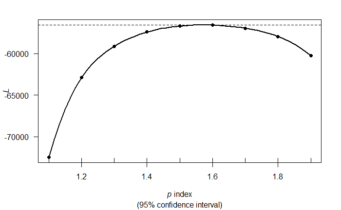

```r
start <- Sys.time()
# identity link
output <- tweedie.profile(claimcst0~1, data=dataCar, link.power=1,
                          method="interpolation", verbose=2,
                          do.plot=TRUE, do.smooth=TRUE,
                          p.vec=seq(1.1,1.9,.1))
```

```r
end <- Sys.time()
print(end-start)
```

```
Time difference of 21.93294 secs
```

```
1.1 1.15 1.2 1.25 1.3 1.35 1.4 1.45 1.5 1.55 1.6 1.65 1.7 1.75 1.8 1.85 1.9
.................Done.
```

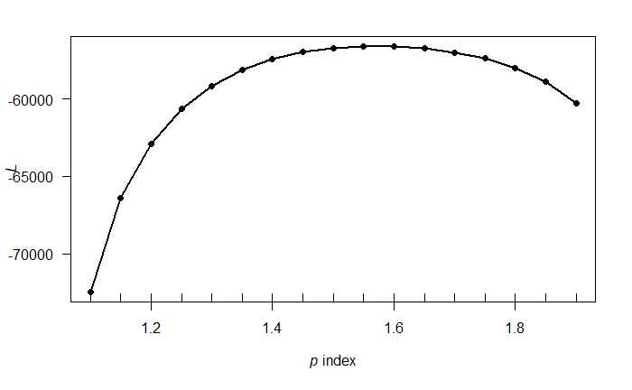

```r
start <- Sys.time()
# identity link
output <- tweedie.profile(claimcst0~1, data=dataCar, link.power=1,
                          method="interpolation",
                          do.plot=TRUE, do.smooth=FALSE,
                          p.vec=seq(1.1,1.9,.05))
```

```r
end <- Sys.time()
print(end-start)
```

```
Time difference of 36.84235 secs
```

```r
output$p.max
```

```
[1] 1.55
```

```r
output$phi.max
```

```
[1] 288.9472
```

```
1.1 1.125 1.15 1.175 1.2 1.225 1.25 1.275 1.3 1.325 1.35 1.375 1.4 1.425 1.45 1.475 1.5 1.525 1.55 1.575 1.6 1.625 1.65 1.675 1.7 1.725 1.75 1.775 1.8 1.825 1.85 1.875 1.9
.................................Done.
```

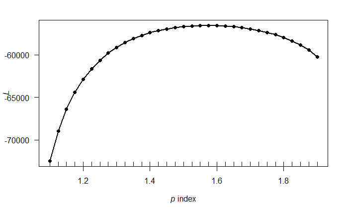

```r
start <- Sys.time()
# identity link
output <- tweedie.profile(claimcst0~1, data=dataCar, link.power=1,
                          method="interpolation",
                          do.plot=TRUE, do.smooth=FALSE,
                          p.vec=seq(1.1,1.9,.025))
```

```r
end <- Sys.time()
print(end-start)
```

```
Time difference of 1.173286 mins
```

```r
output$p.max
```

```
[1] 1.575
```

```r
output$phi.max
```

```
[1] 270.5084
```

```
1.1 1.11 1.12 1.13 1.14 1.15 1.16 1.17 1.18 1.19 1.2 1.21 1.22 1.23 1.24 1.25 1.26 1.27 1.28 1.29 1.3 1.31 1.32 1.33 1.34 1.35 1.36 1.37 1.38 1.39 1.4 1.41 1.42 1.43 1.44 1.45 1.46 1.47 1.48 1.49 1.5 1.51 1.52 1.53 1.54 1.55 1.56 1.57 1.58 1.59 1.6 1.61 1.62 1.63 1.64 1.65 1.66 1.67 1.68 1.69 1.7 1.…
.................................................................................Done.
```

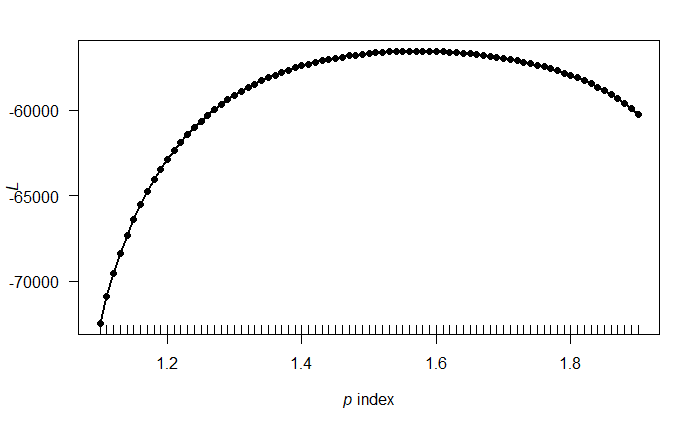

```r
start <- Sys.time()
# identity link
output <- tweedie.profile(claimcst0~1, data=dataCar, link.power=1,
                          method="interpolation",
                          do.plot=TRUE, do.smooth=FALSE,
                          p.vec=seq(1.1,1.9,.01))
```

```r
end <- Sys.time()
print(end-start)
```

```
Time difference of 2.814754 mins
```

```r
output$p.max
```

```
[1] 1.57
```

```r
output$phi.max
```

```
[1] 274.034
```

```
1.3 1.31 1.32 1.33 1.34 1.35 1.36 1.37 1.38 1.39 1.4 1.41 1.42 1.43 1.44 1.45 1.46 1.47 1.48 1.49 1.5 1.51 1.52 1.53 1.54 1.55 1.56 1.57 1.58 1.59 1.6 1.61 1.62 1.63 1.64 1.65 1.66 1.67 1.68 1.69 1.7
.........................................Done.
```

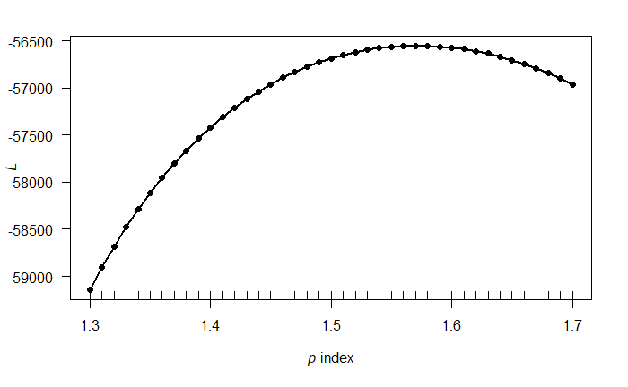

```r
start <- Sys.time()
# identity link
output <- tweedie.profile(claimcst0~1, data=dataCar, link.power=1,
                          method="interpolation",
                          do.plot=TRUE, do.smooth=FALSE,
                          p.vec=seq(1.3,1.7,.01))
```

```r
end <- Sys.time()
print(end-start)
```

```
Time difference of 1.337427 mins
```

```r
output$p.max
```

```
[1] 1.57
```

```r
output$phi.max
```

```
[1] 274.034
```

MLE gives that p=1.57.

```r
m5 <- glm(claimcst0~1+as.factor(gender)+as.factor(agecat)
          +as.factor(area)+veh_value,
          data=dataCar,
          family=tweedie(link.power=0, var.power=1.57))
```

Feedback functions.

```r
give_feedback <- function(model){
  SSR <- sum((model$residuals)**2)
  fitted_values <- model$fitted.values
  print("Squared Sum of Residuals"); print(SSR)
  print("Deviance"); print(model$deviance)
  print("AIC"); print(AICtweedie(model))
}
compare_insurance_models <- function(model1, model2){

  SSR1 <- sum((model1$residuals)**2)
  SSR2 <- sum((model2$residuals)**2)
  diff_SSR <- SSR1 - SSR2

  fitted_values1 <- model1$fitted.values
  fitted_values2 <- model2$fitted.values
  diff_fitted_values <- fitted_values1 - fitted_values2
  diff_losses <- sum(abs(diff_fitted_values))
  diff_econ = sum(model1$fitted.values - model2$fitted.values)

  diff_deviance <- model1$deviance - model2$deviance
  diff_AIC <- AICtweedie(model1) - AICtweedie(model2)

  print("Model differences are relative to the first model")
  print("Squared Sum of Residuals"); print(diff_SSR)
  print("Deviance"); print(diff_deviance)
  print("AIC"); print(diff_AIC)

  print("Sum of absolute differences between losses"); print(diff_losses)
  print("Total difference between losses"); print(diff_econ)

  print("First 10 differences in fitted losses")
  print(diff_fitted_values[1:5])

}
```

```r
give_feedback(m4)
```

```
[1] "Squared Sum of Residuals"
[1] 3856416
[1] "Deviance"
[1] 4946788
[1] "AIC"
[1] 147451.1
```

```r
give_feedback(m5)
```

```
[1] "Squared Sum of Residuals"
[1] 3856500
[1] "Deviance"
[1] 3740250
[1] "AIC"
[1] 148535.7
```

```r
compare_insurance_models(m5,m4)
```

```
[1] "Model differences are relative to the first model"
[1] "Squared Sum of Residuals"
[1] 83.86024
[1] "Deviance"
[1] -1206538
[1] "AIC"
[1] 1084.598
[1] "Sum of absolute differences between losses"
[1] 13443.74
[1] "Total difference between losses"
[1] -741.8077
[1] "First 10 differences in fitted losses"
         1          2          3          4          5
 0.4458003  0.1028460 -0.1232175  0.0147526  0.4772812
```

```r
sum(m4$fitted.values)/sum(dataCar$claimcst0)
```

```
[1] 0.9996216
```

```r
sum(m5$fitted.values)/sum(dataCar$claimcst0)
```

```
[1] 0.999542
```

Essentially, we see no difference. Sometimes actuaries use p=1.33 or p=1.66 as defaults. Let’s see how things change if we use those p values.

```r
m6 <- glm(claimcst0~1+as.factor(gender)+as.factor(agecat)
          +as.factor(area)+veh_value,
          data=dataCar,
          family=tweedie(link.power=0, var.power=1.33))
m7 <- glm(claimcst0~1+as.factor(gender)+as.factor(agecat)
          +as.factor(area)+veh_value,
          data=dataCar,
          family=tweedie(link.power=0, var.power=1.66))
```

```r
compare_insurance_models(m5,m6)
```

```
[1] "Model differences are relative to the first model"
[1] "Squared Sum of Residuals"
[1] -531.9685
[1] "Deviance"
[1] -7011902
[1] "AIC"
[1] 2558.144
[1] "Sum of absolute differences between losses"
[1] 47207.76
[1] "Total difference between losses"
[1] -2455.577
[1] "First 10 differences in fitted losses"
         1          2          3          4          5
 1.5470961  0.3652896 -0.4300347  0.1478511  1.6527910
```

```r
compare_insurance_models(m5,m7)
```

```
[1] "Model differences are relative to the first model"
[1] "Squared Sum of Residuals"
[1] -334.0136
[1] "Deviance"
[1] 999727.4
[1] "AIC"
[1] -1817.047
[1] "Sum of absolute differences between losses"
[1] 16938.97
[1] "Total difference between losses"
[1] 937.6214
[1] "First 10 differences in fitted losses"
          1           2           3           4           5
-0.56732177 -0.12817094  0.15448050  0.01099919 -0.60827595
```

An observation. - We see some trends in how AIC and total difference change as p changes. Another observation. - I find it curious that deviance and AIC move in different directions for this data.

```r
sum(m5$fitted.values)/sum(dataCar$claimcst0)
```

```
[1] 0.999542
```

```r
sum(m6$fitted.values)/sum(dataCar$claimcst0)
```

```
[1] 0.9998056
```

```r
sum(m7$fitted.values)/sum(dataCar$claimcst0)
```

```
[1] 0.9994413
```

Again, we see little change. Insurance companies want to implement new techonologies if the tech provides big advantages. Here we only see changes in the order of cents. Granted, p=1.33, p=1.5, p=1.57, and 1.66 all correspond to a Poisson-gamma model. (I guess there isn’t much difference between the Poisson-gamam models for this dataset.)

We have 67856 observations. So the dataset is large. However, we have few features to differentiate between the observations. We will see if the power parameter plays a more significant role in a more complicated model.